# usa_india

```python
import pandas as pd
import numpy as np
```

```python
imdb_titles = pd.read_csv('IMDb movies.csv', encoding="utf-8", na_values="Unknown", encoding_errors="replace")
imdb_ratings = pd.read_csv("IMDb ratings.csv", usecols=["imdb_title_id", "weighted_average_vote"])
imdb = imdb_titles.merge(imdb_ratings, left_on="imdb_title_id", right_on="imdb_title_id", how="inner")
imdb
```

|  | imdb_title_id | title | original_title | year | date_published | genre | duration | country | language | director | ... | description | avg_vote | votes | budget | usa_gross_income | worlwide_gross_income | metascore | reviews_from_users | reviews_from_critics | weighted_average_vote |
| --- | --- | --- | --- | --- | --- | --- | --- | --- | --- | --- | --- | --- | --- | --- | --- | --- | --- | --- | --- | --- | --- |
| 0 | tt0000009 | Miss Jerry | Miss Jerry | 1894 | 1894-10-09 | Romance | 45 | USA | NaN | Alexander Black | ... | The adventures of a female reporter in the 1890s. | 5.9 | 154 | NaN | NaN | NaN | NaN | 1.0 | 2.0 | 5.9 |
| 1 | tt0000574 | The Story of the Kelly Gang | The Story of the Kelly Gang | 1906 | 1906-12-26 | Biography, Crime, Drama | 70 | Australia | NaN | Charles Tait | ... | True story of notorious Australian outlaw Ned ... | 6.1 | 589 | $ 2250 | NaN | NaN | NaN | 7.0 | 7.0 | 6.1 |
| 2 | tt0001892 | Den sorte dr�m | Den sorte dr�m | 1911 | 1911-08-19 | Drama | 53 | Germany, Denmark | NaN | Urban Gad | ... | Two men of high rank are both wooing the beaut... | 5.8 | 188 | NaN | NaN | NaN | NaN | 5.0 | 2.0 | 5.8 |
| 3 | tt0002101 | Cleopatra | Cleopatra | 1912 | 1912-11-13 | Drama, History | 100 | USA | English | Charles L. Gaskill | ... | The fabled queen of Egypt's affair with Roman ... | 5.2 | 446 | $ 45000 | NaN | NaN | NaN | 25.0 | 3.0 | 5.2 |
| 4 | tt0002130 | L'Inferno | L'Inferno | 1911 | 1911-03-06 | Adventure, Drama, Fantasy | 68 | Italy | Italian | Francesco Bertolini, Adolfo Padovan | ... | Loosely adapted from Dante's Divine Comedy and... | 7.0 | 2237 | NaN | NaN | NaN | NaN | 31.0 | 14.0 | 7.0 |
| ... | ... | ... | ... | ... | ... | ... | ... | ... | ... | ... | ... | ... | ... | ... | ... | ... | ... | ... | ... | ... | ... |
| 85850 | tt9908390 | Le lion | Le lion | 2020 | 2020-01-29 | Comedy | 95 | France, Belgium | French | Ludovic Colbeau-Justin | ... | A psychiatric hospital patient pretends to be ... | 5.3 | 398 | NaN | NaN | $ 3507171 | NaN | NaN | 4.0 | 5.3 |
| 85851 | tt9911196 | De Beentjes van Sint-Hildegard | De Beentjes van Sint-Hildegard | 2020 | 2020-02-13 | Comedy, Drama | 103 | Netherlands | German, Dutch | Johan Nijenhuis | ... | A middle-aged veterinary surgeon believes his ... | 7.7 | 724 | NaN | NaN | $ 7299062 | NaN | 6.0 | 4.0 | 7.7 |
| 85852 | tt9911774 | Padmavyuhathile Abhimanyu | Padmavyuhathile Abhimanyu | 2019 | 2019-03-08 | Drama | 130 | India | Malayalam | Vineesh Aaradya | ... | NaN | 7.9 | 265 | NaN | NaN | NaN | NaN | NaN | NaN | 7.9 |
| 85853 | tt9914286 | Sokagin �ocuklari | Sokagin �ocuklari | 2019 | 2019-03-15 | Drama, Family | 98 | Turkey | Turkish | Ahmet Faik Akinci | ... | NaN | 6.4 | 194 | NaN | NaN | $ 2833 | NaN | NaN | NaN | 6.4 |
| 85854 | tt9914942 | La vida sense la Sara Amat | La vida sense la Sara Amat | 2019 | 2020-02-05 | Drama | 74 | Spain | Catalan | Laura Jou | ... | Pep, a 13-year-old boy, is in love with a girl... | 6.7 | 102 | NaN | NaN | $ 59794 | NaN | NaN | 2.0 | 6.7 |

85855 rows × 23 columns

As per the analysis made for the indian movie dataset the major columns for the analysis are: imdb_title_id, title, year, date_published, genre, language, country, director, writer, actors, production_company,description, weighted_average_vote

```python
imdb_movies = imdb[["imdb_title_id", "title", "year", "date_published", "genre", "language", "country", "director", "writer", "actors", "production_company", "description", "weighted_average_vote"]]
imdb_movies
```

|  | imdb_title_id | title | year | date_published | genre | language | country | director | writer | actors | production_company | description | weighted_average_vote |
| --- | --- | --- | --- | --- | --- | --- | --- | --- | --- | --- | --- | --- | --- |
| 0 | tt0000009 | Miss Jerry | 1894 | 1894-10-09 | Romance | NaN | USA | Alexander Black | Alexander Black | Blanche Bayliss, William Courtenay, Chauncey D... | Alexander Black Photoplays | The adventures of a female reporter in the 1890s. | 5.9 |
| 1 | tt0000574 | The Story of the Kelly Gang | 1906 | 1906-12-26 | Biography, Crime, Drama | NaN | Australia | Charles Tait | Charles Tait | Elizabeth Tait, John Tait, Norman Campbell, Be... | J. and N. Tait | True story of notorious Australian outlaw Ned ... | 6.1 |
| 2 | tt0001892 | Den sorte dr�m | 1911 | 1911-08-19 | Drama | NaN | Germany, Denmark | Urban Gad | Urban Gad, Gebhard Sch�tzler-Perasini | Asta Nielsen, Valdemar Psilander, Gunnar Helse... | Fotorama | Two men of high rank are both wooing the beaut... | 5.8 |
| 3 | tt0002101 | Cleopatra | 1912 | 1912-11-13 | Drama, History | English | USA | Charles L. Gaskill | Victorien Sardou | Helen Gardner, Pearl Sindelar, Miss Fielding, ... | Helen Gardner Picture Players | The fabled queen of Egypt's affair with Roman ... | 5.2 |
| 4 | tt0002130 | L'Inferno | 1911 | 1911-03-06 | Adventure, Drama, Fantasy | Italian | Italy | Francesco Bertolini, Adolfo Padovan | Dante Alighieri | Salvatore Papa, Arturo Pirovano, Giuseppe de L... | Milano Film | Loosely adapted from Dante's Divine Comedy and... | 7.0 |
| ... | ... | ... | ... | ... | ... | ... | ... | ... | ... | ... | ... | ... | ... |
| 85850 | tt9908390 | Le lion | 2020 | 2020-01-29 | Comedy | French | France, Belgium | Ludovic Colbeau-Justin | Alexandre Coquelle, Matthieu Le Naour | Dany Boon, Philippe Katerine, Anne Serra, Samu... | Monkey Pack Films | A psychiatric hospital patient pretends to be ... | 5.3 |
| 85851 | tt9911196 | De Beentjes van Sint-Hildegard | 2020 | 2020-02-13 | Comedy, Drama | German, Dutch | Netherlands | Johan Nijenhuis | Radek Bajgar, Herman Finkers | Herman Finkers, Johanna ter Steege, Leonie ter... | Johan Nijenhuis & Co | A middle-aged veterinary surgeon believes his ... | 7.7 |
| 85852 | tt9911774 | Padmavyuhathile Abhimanyu | 2019 | 2019-03-08 | Drama | Malayalam | India | Vineesh Aaradya | Vineesh Aaradya, Vineesh Aaradya | Anoop Chandran, Indrans, Sona Nair, Simon Brit... | RMCC Productions | NaN | 7.9 |
| 85853 | tt9914286 | Sokagin �ocuklari | 2019 | 2019-03-15 | Drama, Family | Turkish | Turkey | Ahmet Faik Akinci | Ahmet Faik Akinci, Kasim U�kan | Ahmet Faik Akinci, Belma Mamati, Metin Ke�eci,... | Gizem Ajans | NaN | 6.4 |
| 85854 | tt9914942 | La vida sense la Sara Amat | 2019 | 2020-02-05 | Drama | Catalan | Spain | Laura Jou | Coral Cruz, Pep Puig | Maria Morera Colomer, Biel Rossell Pelfort, Is... | La Xarxa de Comunicaci� Local | Pep, a 13-year-old boy, is in love with a girl... | 6.7 |

85855 rows × 13 columns

Getting data of movie which belongs to the country USA and India

```python
usa_india_movie = imdb_movies[imdb_movies["country"] == "USA"]
usa_india_movie = pd.concat([usa_india_movie, imdb_movies[imdb_movies["country"] == "India"]])
usa_india_movie
```

|  | imdb_title_id | title | year | date_published | genre | language | country | director | writer | actors | production_company | description | weighted_average_vote |
| --- | --- | --- | --- | --- | --- | --- | --- | --- | --- | --- | --- | --- | --- |
| 0 | tt0000009 | Miss Jerry | 1894 | 1894-10-09 | Romance | NaN | USA | Alexander Black | Alexander Black | Blanche Bayliss, William Courtenay, Chauncey D... | Alexander Black Photoplays | The adventures of a female reporter in the 1890s. | 5.9 |
| 3 | tt0002101 | Cleopatra | 1912 | 1912-11-13 | Drama, History | English | USA | Charles L. Gaskill | Victorien Sardou | Helen Gardner, Pearl Sindelar, Miss Fielding, ... | Helen Gardner Picture Players | The fabled queen of Egypt's affair with Roman ... | 5.2 |
| 5 | tt0002199 | From the Manger to the Cross; or, Jesus of Naz... | 1912 | 1913 | Biography, Drama | English | USA | Sidney Olcott | Gene Gauntier | R. Henderson Bland, Percy Dyer, Gene Gauntier,... | Kalem Company | An account of the life of Jesus Christ, based ... | 5.7 |
| 17 | tt0003167 | Amore di madre | 1914 | 1914-05-17 | Drama | English | USA | D.W. Griffith | D.W. Griffith, H.E. Aitken | Henry B. Walthall, Josephine Crowell, Lillian ... | Majestic Motion Picture Company | John Howard Payne at his most miserable point ... | 5.8 |
| 19 | tt0003471 | Traffic in Souls | 1913 | 1913-11-24 | Crime, Drama | English | USA | George Loane Tucker | NaN | Jane Gail, Ethel Grandin, William H. Turner, M... | Independent Moving Pictures Co. of America (IMP) | A woman, with the aid of her police officer sw... | 6.0 |
| ... | ... | ... | ... | ... | ... | ... | ... | ... | ... | ... | ... | ... | ... |
| 85844 | tt9903716 | Jessie | 2019 | 2019-03-15 | Horror, Thriller | Telugu | India | Aswani Kumar V. | Aswani Kumar V. | Ashima Narwal, Sritha Chandana, Atul Kulkarni,... | Ekaa Art Production | Set in an abandoned house, the film follows a ... | 7.0 |
| 85847 | tt9905412 | Ottam | 2019 | 2019-03-08 | Drama | Malayalam | India | Zam | Rajesh k Narayan | Nandu Anand, Roshan Ullas, Manikandan R. Achar... | Thomas Thiruvalla Films | Set in Trivandrum, the story of Ottam unfolds ... | 7.4 |
| 85848 | tt9905462 | Pengalila | 2019 | 2019-03-08 | Drama | Malayalam | India | T.V. Chandran | T.V. Chandran | Lal, Akshara Kishor, Iniya, Narain, Renji Pani... | Benzy Productions | An unusual bond between a sixty year old Dalit... | 8.8 |
| 85849 | tt9906644 | Manoharam | 2019 | 2019-09-27 | Comedy, Drama | Malayalam | India | Anvar Sadik | NaN | Vineeth Sreenivasan, Aparna Das, Basil Joseph,... | chakkalakal Films | Manoharan is a poster artist struggling to fin... | 6.8 |
| 85852 | tt9911774 | Padmavyuhathile Abhimanyu | 2019 | 2019-03-08 | Drama | Malayalam | India | Vineesh Aaradya | Vineesh Aaradya, Vineesh Aaradya | Anoop Chandran, Indrans, Sona Nair, Simon Brit... | RMCC Productions | NaN | 7.9 |

34576 rows × 13 columns

There is one observation which as value in year as "TV Movie 2019" changin it in to 2019

```python
usa_india_movie.loc[usa_india_movie["year"] == "TV Movie 2019","year"] = 2019
```

```python
usa_india_movie["year"] = usa_india_movie["year"].astype(int)
usa_india_movie.groupby(by="year").size()
```

```
year
1894       1
1912       2
1913       1
1914      16
1915      15
        ...
2016    1193
2017    1269
2018    1283
2019    1146
2020     417
Length: 110, dtype: int64
```

As recent vieweres don't like too much to watch old movie so taking the movies from year 1990 for this dataset

```python
usa_india_movie_1990 = usa_india_movie[usa_india_movie["year"] >= 1990]
usa_india_movie_1990
```

|  | imdb_title_id | title | year | date_published | genre | language | country | director | writer | actors | production_company | description | weighted_average_vote |
| --- | --- | --- | --- | --- | --- | --- | --- | --- | --- | --- | --- | --- | --- |
| 4334 | tt0035423 | Kate & Leopold | 2001 | 2002-03-01 | Comedy, Fantasy, Romance | English, French | USA | James Mangold | Steven Rogers, James Mangold | Meg Ryan, Hugh Jackman, Liev Schreiber, Brecki... | Konrad Pictures | An English Duke from 1876 is inadvertedly drag... | 6.4 |
| 19545 | tt0081145 | Harry e Carota | 1993 | 1993-10-22 | Comedy, Crime, Drama | English | USA | Dan Curtis | Stanley Cohen, Richard Tannenbaum | Danny Aiello, Alex Zuckerman, Joe Pantoliano, ... | Dan Curtis Productions | A lonely and emotionally neglected rich kid fo... | 5.4 |
| 21806 | tt0088751 | The Naked Monster | 2005 | 2005-04-22 | Comedy, Horror, Sci-Fi | English | USA | Wayne Berwick, Ted Newsom | Ted Newsom | Kenneth Tobey, Brinke Stevens, R.G. Wilson, Jo... | Heidelberg Films | A brain-dead sheriff, a stolid secret agent an... | 5.4 |
| 23805 | tt0094900 | Committed | 1991 | 1991-04-18 | Drama, Thriller | English | USA | William A. Levey | Susan Claudia, Simon Last | Jennifer O'Neill, Robert Forster, William Wind... | World Wide Entertainment | A nurse is taken hostage by a patient pretendi... | 5.1 |
| 24113 | tt0095745 | Ninja Vengeance | 1993 | 1993-02-01 | Action, Drama | English | USA | Karl Armstrong | Karl Armstrong, Carrie Armstrong | Janet Pawlak, David Paul Lord, Craig Boyett, C... | 21st Century Film Corporation | After he witnesses the death of a black law st... | 2.2 |
| ... | ... | ... | ... | ... | ... | ... | ... | ... | ... | ... | ... | ... | ... |
| 85844 | tt9903716 | Jessie | 2019 | 2019-03-15 | Horror, Thriller | Telugu | India | Aswani Kumar V. | Aswani Kumar V. | Ashima Narwal, Sritha Chandana, Atul Kulkarni,... | Ekaa Art Production | Set in an abandoned house, the film follows a ... | 7.0 |
| 85847 | tt9905412 | Ottam | 2019 | 2019-03-08 | Drama | Malayalam | India | Zam | Rajesh k Narayan | Nandu Anand, Roshan Ullas, Manikandan R. Achar... | Thomas Thiruvalla Films | Set in Trivandrum, the story of Ottam unfolds ... | 7.4 |
| 85848 | tt9905462 | Pengalila | 2019 | 2019-03-08 | Drama | Malayalam | India | T.V. Chandran | T.V. Chandran | Lal, Akshara Kishor, Iniya, Narain, Renji Pani... | Benzy Productions | An unusual bond between a sixty year old Dalit... | 8.8 |
| 85849 | tt9906644 | Manoharam | 2019 | 2019-09-27 | Comedy, Drama | Malayalam | India | Anvar Sadik | NaN | Vineeth Sreenivasan, Aparna Das, Basil Joseph,... | chakkalakal Films | Manoharan is a poster artist struggling to fin... | 6.8 |
| 85852 | tt9911774 | Padmavyuhathile Abhimanyu | 2019 | 2019-03-08 | Drama | Malayalam | India | Vineesh Aaradya | Vineesh Aaradya, Vineesh Aaradya | Anoop Chandran, Indrans, Sona Nair, Simon Brit... | RMCC Productions | NaN | 7.9 |

21244 rows × 13 columns

Checking is there any duplicate ids in the dataset

```python
usa_india_movie_1990.duplicated("imdb_title_id").sum()
```

```
0
```

```python
usa_india_movie_1990.isna().sum()
```

```
imdb_title_id               0
title                       0
year                        0
date_published              0
genre                       0
language                  270
country                     0
director                   42
writer                    656
actors                     21
production_company       1412
description               117
weighted_average_vote       0
dtype: int64
```

Dropping values which null values in language and description

```python
usa_india_movie_1990.shape
```

```
(21244, 13)
```

```python
usa_india_movie_1990 = usa_india_movie_1990.dropna(subset=["language", "description"])
usa_india_movie_1990.isna().sum()
```

```
imdb_title_id               0
title                       0
year                        0
date_published              0
genre                       0
language                    0
country                     0
director                   37
writer                    624
actors                     16
production_company       1374
description                 0
weighted_average_vote       0
dtype: int64
```

```python
usa_india_movie_1990.shape
```

```
(20858, 13)
```

total 386 movies are dropped from the dataset

And checking once again is there in duplicate ids

```python
usa_india_movie_1990.duplicated("imdb_title_id").sum()
```

```
0
```

```python
usa_india_movie_1990.groupby(by="language").size().sort_values(ascending=False)
```

```
language
English                                      14137
Hindi                                         1592
Malayalam                                      741
Tamil                                          738
Telugu                                         600
                                             ...
English, Lao                                     1
English, Korean, Russian, Spanish                1
English, Korean, Persian, Spanish, Arabic        1
English, Korean, Icelandic, Russian              1
Yiddish, English, Spanish                        1
Length: 662, dtype: int64
```

There are 662 distinct categories in the dataset

As there are multiple languages spearated by commas so splited movies by single language and created new title id

```python
import random

usa_indian_movies_languages = pd.DataFrame(columns=["imdb_title_id", "title", "year", "date_published", "genre", "language", "country", "director", "writer", "actors", "production_company", "description", "weighted_average_vote"])
for index, row in usa_india_movie_1990.iterrows():
    lan = str(row["language"]).split(", ")
    if len(lan) != 1:
        for i in range(len(lan)):
            new_row = row.copy(deep=True)
            while True:
                title_id = "tt" + str(random.randint(1000000, 2000000))
                if title_id not in usa_india_movie_1990["imdb_title_id"].to_list() and title_id not in \
                        usa_indian_movies_languages["imdb_title_id"].to_list():
                    new_row["imdb_title_id"] = title_id
                    break
            new_row["title"] = str(new_row["title"]) + f"({lan[i]})"
            new_row["language"] = lan[i]
            usa_indian_movies_languages = usa_indian_movies_languages._append(new_row)
    else:
        usa_indian_movies_languages = usa_indian_movies_languages._append(row)
usa_indian_movies_languages
```

|  | imdb_title_id | title | year | date_published | genre | language | country | director | writer | actors | production_company | description | weighted_average_vote |
| --- | --- | --- | --- | --- | --- | --- | --- | --- | --- | --- | --- | --- | --- |
| 4334 | tt1438038 | Kate & Leopold(English) | 2001 | 2002-03-01 | Comedy, Fantasy, Romance | English | USA | James Mangold | Steven Rogers, James Mangold | Meg Ryan, Hugh Jackman, Liev Schreiber, Brecki... | Konrad Pictures | An English Duke from 1876 is inadvertedly drag... | 6.4 |
| 4334 | tt1527721 | Kate & Leopold(French) | 2001 | 2002-03-01 | Comedy, Fantasy, Romance | French | USA | James Mangold | Steven Rogers, James Mangold | Meg Ryan, Hugh Jackman, Liev Schreiber, Brecki... | Konrad Pictures | An English Duke from 1876 is inadvertedly drag... | 6.4 |
| 19545 | tt0081145 | Harry e Carota | 1993 | 1993-10-22 | Comedy, Crime, Drama | English | USA | Dan Curtis | Stanley Cohen, Richard Tannenbaum | Danny Aiello, Alex Zuckerman, Joe Pantoliano, ... | Dan Curtis Productions | A lonely and emotionally neglected rich kid fo... | 5.4 |
| 21806 | tt0088751 | The Naked Monster | 2005 | 2005-04-22 | Comedy, Horror, Sci-Fi | English | USA | Wayne Berwick, Ted Newsom | Ted Newsom | Kenneth Tobey, Brinke Stevens, R.G. Wilson, Jo... | Heidelberg Films | A brain-dead sheriff, a stolid secret agent an... | 5.4 |
| 23805 | tt0094900 | Committed | 1991 | 1991-04-18 | Drama, Thriller | English | USA | William A. Levey | Susan Claudia, Simon Last | Jennifer O'Neill, Robert Forster, William Wind... | World Wide Entertainment | A nurse is taken hostage by a patient pretendi... | 5.1 |
| ... | ... | ... | ... | ... | ... | ... | ... | ... | ... | ... | ... | ... | ... |
| 85843 | tt9900782 | Kaithi | 2019 | 2019-10-25 | Action, Thriller | Tamil | India | Lokesh Kanagaraj | Lokesh Kanagaraj, Pon Parthiban | Karthi, Narain, Ramana, George Maryan, Harish ... | Dream Warrior Pictures | A recently released prisoner becomes involved ... | 8.5 |
| 85844 | tt9903716 | Jessie | 2019 | 2019-03-15 | Horror, Thriller | Telugu | India | Aswani Kumar V. | Aswani Kumar V. | Ashima Narwal, Sritha Chandana, Atul Kulkarni,... | Ekaa Art Production | Set in an abandoned house, the film follows a ... | 7.0 |
| 85847 | tt9905412 | Ottam | 2019 | 2019-03-08 | Drama | Malayalam | India | Zam | Rajesh k Narayan | Nandu Anand, Roshan Ullas, Manikandan R. Achar... | Thomas Thiruvalla Films | Set in Trivandrum, the story of Ottam unfolds ... | 7.4 |
| 85848 | tt9905462 | Pengalila | 2019 | 2019-03-08 | Drama | Malayalam | India | T.V. Chandran | T.V. Chandran | Lal, Akshara Kishor, Iniya, Narain, Renji Pani... | Benzy Productions | An unusual bond between a sixty year old Dalit... | 8.8 |
| 85849 | tt9906644 | Manoharam | 2019 | 2019-09-27 | Comedy, Drama | Malayalam | India | Anvar Sadik | NaN | Vineeth Sreenivasan, Aparna Das, Basil Joseph,... | chakkalakal Films | Manoharan is a poster artist struggling to fin... | 6.8 |

24288 rows × 13 columns

After splitting by language total movies are 24288

Checking whether there are any duplicate ids

```python
usa_indian_movies_languages.duplicated("imdb_title_id").sum()
```

```
0
```

Seeing the distribution using languages

```python
languages = usa_indian_movies_languages.groupby(by="language").size().reset_index(name="count")
languages = languages.sort_values(by="count",ascending=False)
languages
```

|  | language | count |
| --- | --- | --- |
| 31 | English | 16111 |
| 44 | Hindi | 2197 |
| 122 | Tamil | 956 |
| 123 | Telugu | 815 |
| 71 | Malayalam | 797 |
| ... | ... | ... |
| 75 | Maya | 1 |
| 73 | Manipuri | 1 |
| 1 | Akan | 1 |
| 69 | Maithili | 1 |
| 140 | Zulu | 1 |

141 rows × 2 columns

There 141 languages present in the dataset

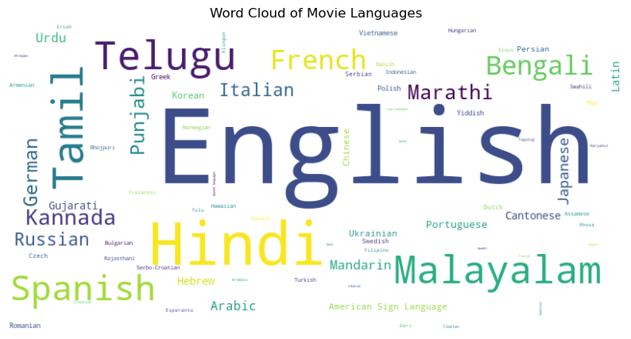

```python
    from wordcloud import WordCloud
import matplotlib.pyplot as plt

# Assuming 'languages' is a pandas DataFrame with 'language' and 'count' columns
word_freq_dict = dict(zip(languages['language'], languages['count']))

# Creating a WordCloud object
wordcloud = WordCloud(width=800, height=400, background_color='white').generate_from_frequencies(word_freq_dict)

# Plotting the WordCloud
plt.figure(figsize=(10, 6))
plt.imshow(wordcloud, interpolation='bilinear')
plt.axis('off')
plt.title('Word Cloud of Movie Languages')
plt.show()
```

```python
languages_head = languages[languages["count"] >100]
languages_head
```

|  | language | count |
| --- | --- | --- |
| 31 | English | 16111 |
| 44 | Hindi | 2197 |
| 122 | Tamil | 956 |
| 123 | Telugu | 815 |
| 71 | Malayalam | 797 |
| 116 | Spanish | 631 |
| 35 | French | 343 |
| 13 | Bengali | 321 |
| 56 | Kannada | 206 |
| 74 | Marathi | 180 |
| 37 | German | 170 |
| 97 | Punjabi | 166 |
| 54 | Italian | 146 |
| 102 | Russian | 142 |

```python
languages_head["count"].sum() - languages["count"].sum()
```

```
-1107
```

```python
languages_head = languages_head._append({"language":"Others","count":218}, ignore_index=True)
languages_head
```

|  | language | count |
| --- | --- | --- |
| 0 | English | 16111 |
| 1 | Hindi | 2197 |
| 2 | Tamil | 956 |
| 3 | Telugu | 815 |
| 4 | Malayalam | 797 |
| 5 | Spanish | 631 |
| 6 | French | 343 |
| 7 | Bengali | 321 |
| 8 | Kannada | 206 |
| 9 | Marathi | 180 |
| 10 | German | 170 |
| 11 | Punjabi | 166 |
| 12 | Italian | 146 |
| 13 | Russian | 142 |
| 14 | Others | 218 |

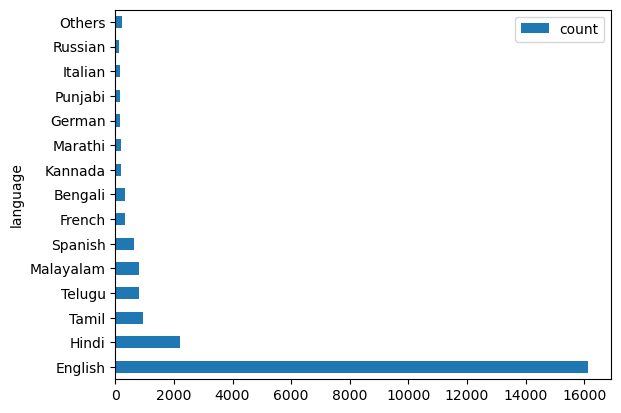

```python
languages_head.plot(x="language", y="count", kind="barh")
```

```python
usa_indian_movies_df = usa_indian_movies_languages[usa_indian_movies_languages["language"].astype(str).str.contains(
    "|".join(languages[languages["count"] > 100]['language'].to_list()))]
usa_indian_movies_df
```

|  | imdb_title_id | title | year | date_published | genre | language | country | director | writer | actors | production_company | description | weighted_average_vote |
| --- | --- | --- | --- | --- | --- | --- | --- | --- | --- | --- | --- | --- | --- |
| 4334 | tt1438038 | Kate & Leopold(English) | 2001 | 2002-03-01 | Comedy, Fantasy, Romance | English | USA | James Mangold | Steven Rogers, James Mangold | Meg Ryan, Hugh Jackman, Liev Schreiber, Brecki... | Konrad Pictures | An English Duke from 1876 is inadvertedly drag... | 6.4 |
| 4334 | tt1527721 | Kate & Leopold(French) | 2001 | 2002-03-01 | Comedy, Fantasy, Romance | French | USA | James Mangold | Steven Rogers, James Mangold | Meg Ryan, Hugh Jackman, Liev Schreiber, Brecki... | Konrad Pictures | An English Duke from 1876 is inadvertedly drag... | 6.4 |
| 19545 | tt0081145 | Harry e Carota | 1993 | 1993-10-22 | Comedy, Crime, Drama | English | USA | Dan Curtis | Stanley Cohen, Richard Tannenbaum | Danny Aiello, Alex Zuckerman, Joe Pantoliano, ... | Dan Curtis Productions | A lonely and emotionally neglected rich kid fo... | 5.4 |
| 21806 | tt0088751 | The Naked Monster | 2005 | 2005-04-22 | Comedy, Horror, Sci-Fi | English | USA | Wayne Berwick, Ted Newsom | Ted Newsom | Kenneth Tobey, Brinke Stevens, R.G. Wilson, Jo... | Heidelberg Films | A brain-dead sheriff, a stolid secret agent an... | 5.4 |
| 23805 | tt0094900 | Committed | 1991 | 1991-04-18 | Drama, Thriller | English | USA | William A. Levey | Susan Claudia, Simon Last | Jennifer O'Neill, Robert Forster, William Wind... | World Wide Entertainment | A nurse is taken hostage by a patient pretendi... | 5.1 |
| ... | ... | ... | ... | ... | ... | ... | ... | ... | ... | ... | ... | ... | ... |
| 85843 | tt9900782 | Kaithi | 2019 | 2019-10-25 | Action, Thriller | Tamil | India | Lokesh Kanagaraj | Lokesh Kanagaraj, Pon Parthiban | Karthi, Narain, Ramana, George Maryan, Harish ... | Dream Warrior Pictures | A recently released prisoner becomes involved ... | 8.5 |
| 85844 | tt9903716 | Jessie | 2019 | 2019-03-15 | Horror, Thriller | Telugu | India | Aswani Kumar V. | Aswani Kumar V. | Ashima Narwal, Sritha Chandana, Atul Kulkarni,... | Ekaa Art Production | Set in an abandoned house, the film follows a ... | 7.0 |
| 85847 | tt9905412 | Ottam | 2019 | 2019-03-08 | Drama | Malayalam | India | Zam | Rajesh k Narayan | Nandu Anand, Roshan Ullas, Manikandan R. Achar... | Thomas Thiruvalla Films | Set in Trivandrum, the story of Ottam unfolds ... | 7.4 |
| 85848 | tt9905462 | Pengalila | 2019 | 2019-03-08 | Drama | Malayalam | India | T.V. Chandran | T.V. Chandran | Lal, Akshara Kishor, Iniya, Narain, Renji Pani... | Benzy Productions | An unusual bond between a sixty year old Dalit... | 8.8 |
| 85849 | tt9906644 | Manoharam | 2019 | 2019-09-27 | Comedy, Drama | Malayalam | India | Anvar Sadik | NaN | Vineeth Sreenivasan, Aparna Das, Basil Joseph,... | chakkalakal Films | Manoharan is a poster artist struggling to fin... | 6.8 |

23185 rows × 13 columns

There are 23185 movies are there after filtering movies as per the languages which have movies less than 100

```python
# usa_indian_movies_df.to_csv("usa_indian_movies_df.csv", index=False)
```

##### Dummy variables for genre is created in the following file: USA Indian movie dataset for dummy variables & USA Indian movie dataset for dummy variables